# p8105_hw1_jz4027

Charlotte Zhang

2025-09-17

# Problem 1

```r
##Load needed library
library(ggplot2)
library(moderndive)
```

### Load dataset

```r
data("early_january_weather")
```

### Short description of the dataset

This dataset has 358 rows and 15 columns.  
Variables include: origin, year, month, day, hour, temp, dewp, humid, wind_dir, wind_speed, wind_gust, precip, pressure, visib, time_hour. The mean temperature is 39.5821229 F.

### ggplot and ggsave

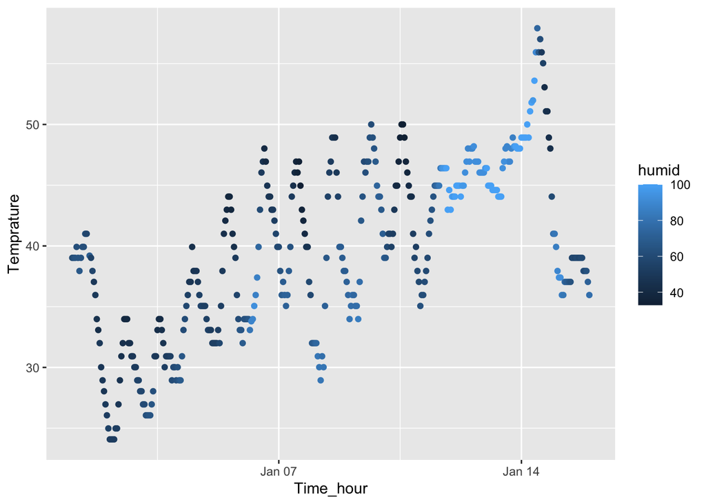

```r
ggplot(early_january_weather, aes(x = time_hour, y = temp, color = humid)) + geom_point() + labs(x = "Time_hour", y = "Temprature")
```

```r
ggsave("p1_scatterplot.pdf", height = 4, width = 6)
```

### Patterns of the scatterplot

- The temperature has an overall increasing trend from early January to mid January
- Temperature increases during daytime and decreases at night, a repeating daily cycle.
- The color of humidity is generally darker in early January (lower humidity), and lighter in mid January (higher humidity).

# Problem 2

```r
library(tidyverse)
set.seed(1)

# Create a data frame
p2_df = tibble(
  norm_samp = rnorm(10),
  log_vec = norm_samp > 0,
  char_vec = c("ab","cd","e","fgh","i","j","k","lmn","o","p"),
  factor_vec = factor(c("Level_1","Level_2","Level_3","Level_2","Level_2","Level_3","Level_1","Level_1","Level_2","Level_3"))
)

# Calculate the mean
mean_norm_samp = mean(pull(p2_df, norm_samp))
mean_log_vec = mean(pull(p2_df, log_vec))
mean_char_vec = mean(pull(p2_df, char_vec))
mean_factor_vec = mean(pull(p2_df, factor_vec))
```

- The mean of a random sample of size 10 from a standard Normal distribution is 0.13. The mean of a logical vector indicating whether elements of the sample are greater than 0 is 0.6. The mean of a character vector of length 10 is NA. The mean of a factor vector of length 10, with 3 different factor “levels” is NA.
- The first one works because it is a numeric variable. The second one is a logical variable, and it works because TRUE=1 and FALSE=0. The last two do not work because they are character and factor variables.

```r
as.numeric(pull(p2_df, log_vec))
as.numeric(pull(p2_df, char_vec))
as.numeric(pull(p2_df, factor_vec))
```

- After converting with as.numeric(), the logical vector becomes 0s and 1s because TRUE = 1 and FALSE = 0. The mean is simply the proportion of TRUEs, which is why we were able to compute it directly even without explicit conversion.
- The character vector becomes a bunch of NAs after converting since letters/words cannot be interpreted as numeric values. And this is why we got NA for the mean.
- The factor vector becomes numbers 1, 2, 3 after converting. These numbers are the underlying integer code each level represent, not real data values. We got NA for the mean before converting because R does not automatically treat them as numeric values.